# Monthly fishing activity in 2023

The Invisible Ocean | B. Monthly change

**111.71 M**estimated fishing hours

**Oct**largest monthly total

**Sep**highest hours per day

## T04 · How did global activity vary by month?

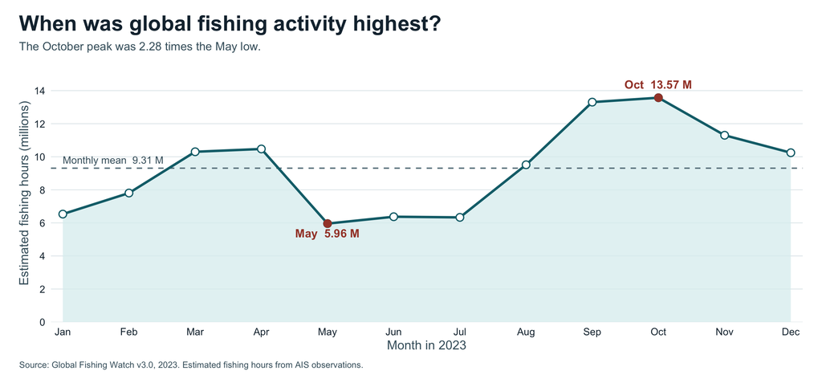

The global total peaked in **Oct at 13.57 million hours**. The low was **May at 5.96 million hours**. The peak was 2.28 times the low. The 12 monthly sums reconcile with the global annual total of 111,712,129 estimated hours.

**Design.** Point position encodes month and total hours on a shared axis. The line links successive months. The dashed reference gives the mean monthly total, and direct labels identify the extrema.

## T05 · Does the peak change after adjusting for month length?

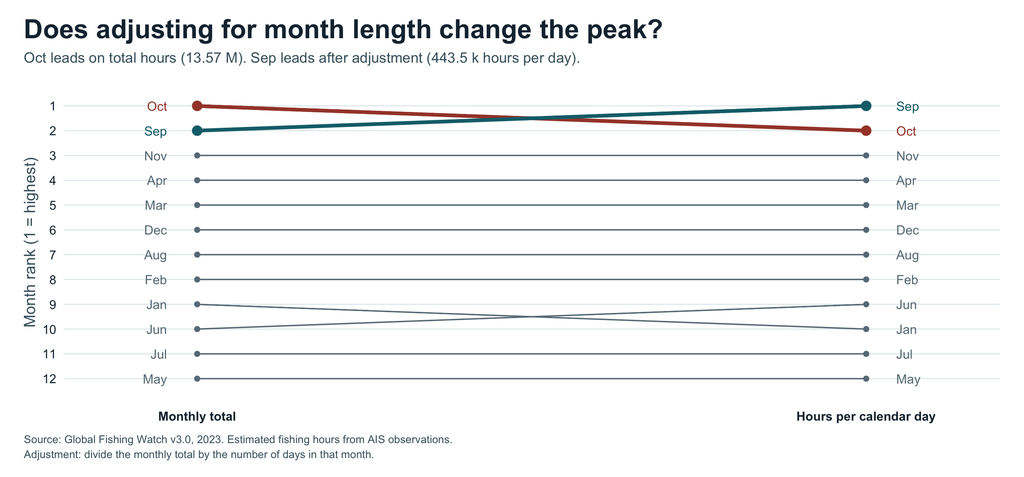

Yes. October recorded **13,571,356 hours in 31 days**, or 437,786 hours per day. September recorded **443,511 hours per day** over 30 days, taking first place after adjustment. February is divided by 28 days.

**Design.** The two axes share the same rank scale. Each line connects the same month across the two measures. Color highlights the two leaders. The crossing makes the reversal visible without putting hours and hours per day on a single quantitative axis.

## T06 · Which areas account for the global peak?

### Global total and regional contributions

**The peak shifts from Oct to Jul once the Northwest Pacific is excluded.** From May to October, the global total rose by 7.61 million estimated hours. The Northwest Pacific rose by 7.97 million hours, while the remaining grid cells fell by 0.35 million. The remainder includes unmatched grid centres.

Hover for estimated hours. Use the area menu below the top chart to compare a region’s monthly shares with the global profile. Both views use the same time axis, so zooming to a period in either view keeps the months aligned.

[interactive chart not shown]

**Design.** The top view uses a common absolute scale and larger dots for the two maxima. The lower view compares the share of each series’ own recorded annual hours, so a lower-volume area can be compared with the global profile. The menu includes the areas with records for all 12 months.

### Peak months across FAO areas

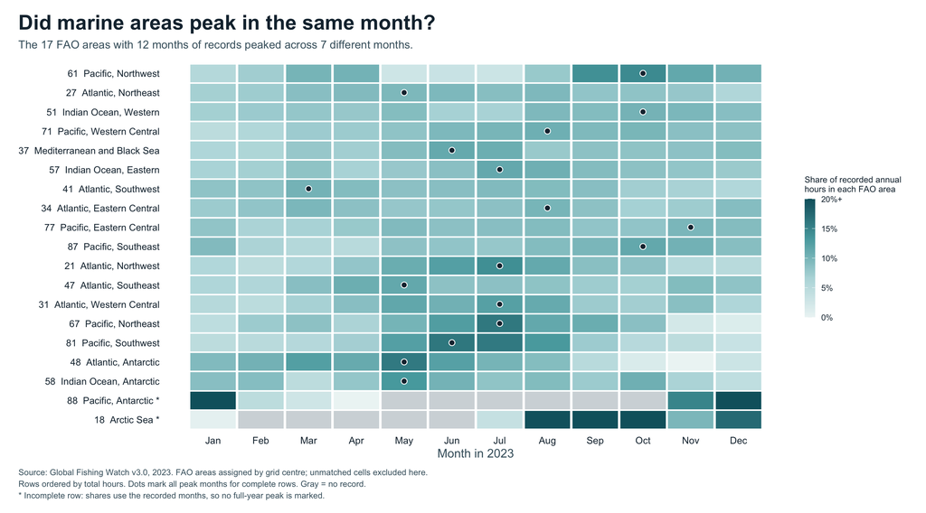

The **17 areas with records for every month** reached their peaks across **7 different months**. The Northwest Pacific (61) peaked in October, the Northeast Atlantic (27) in May, and the Western Central Pacific (71) in August. Arctic Sea (18) and Pacific Antarctic (88) had 7 and 6 months with records, respectively, and are not assigned a full-year peak.

**Design.** Each tile shows the month’s share of the hours recorded that year in its area. This supports a comparison of timing across areas; the values table provides absolute hours. Within a row the peak month has the same ranking under the two measures. The sequential color scale saturates at 20%, and the peak marker makes row maxima identifiable. Gray cells mean that the shared summary has no record for that area-month.

**View monthly values by FAO area**

Choose area

Peak: Oct | Months with records: 12/12

Pacific, Northwest monthly values

| Month | Estimated hours | Share of recorded area-year hours |
| --- | --- | --- |
| Jan | 3,743,088 | 5.5% |
| Feb | 4,910,767 | 7.2% |
| Mar | 6,834,788 | 10.0% |
| Apr | 6,980,595 | 10.2% |
| May | 1,894,833 | 2.8% |
| Jun | 2,273,513 | 3.3% |
| Jul | 2,091,242 | 3.1% |
| Aug | 5,295,477 | 7.8% |
| Sep | 9,559,137 | 14.0% |
| Oct | 9,860,908 | 14.4% |
| Nov | 7,780,326 | 11.4% |
| Dec | 7,069,226 | 10.4% |

## Data & interpretation

- **Data.** Global Fishing Watch v3.0, January–December 2023. The global chart uses all grid centers. The area heatmap uses the 19 official FAO marine areas and excludes 2.09% of global hours from unmatched grid centers.
- **Measure.** These are AIS-derived estimates of fishing activity. They describe the observed 2023 data. Reception and classification differences can affect comparisons. A peak in one year does not establish a repeated seasonal cycle.
- **Sources.** [Global Fishing Watch v3.0](https://doi.org/10.5281/zenodo.14982712) · [FAO marine fishing areas](https://www.fao.org/cwp-on-fishery-statistics/handbook/general-concepts/main-water-areas)